# CCS 消融实验：生物状态关系的跨队列一致性

Bensz Conan

2026-10-10

本报告考察**一组生物状态之间的远近次序，能否在独立患者队列中重复出现**。这是 ablation-03 实验的一部分，结果来自双向投影与 matched-bank 分析，报告仅呈现已有结果。前一份 gene signature 报告比较患者与近邻的连续表达分数，本报告则比较状态之间的关系。近邻名单改变时，状态间的相对位置仍可能相似，因此需要分别考察这两个尺度。

d1 由多个队列模型构成。将它用于跨癌种表示，需要了解原本可在不同队列中辨认的生物状态关系，经过重编码后能否继续辨认。本报告用预先定义的五类 gene signature 检验这一问题；结论限于这些状态，临床效用和等价性仍需另行验证。

## 1 数据概览

reference 与 external bank 分别包含 150 和 43 个模块。正向共有 903 对有效比较。一个队列可以参与多次比较，这些比较之间的依赖需要在统计推断中处理。

## 2 关键函数、参数与源代码位置

| 过程 | 函数与参数 | 约定 | 源代码 |
| --- | --- | --- | --- |
| 状态关系分析的表达输入 | `.asr_extract_anchor_cache()` | 准备阶段固定完整样本范围和 signature | 01.03.00. 生物输入准备.R |
| 生物状态 | `.asr_assign_anchor_states()`；两端各三分之一 | 每个状态至少 8 个样本；分位边界并列时不强制分组 | 02.03.00. 结构复现分析_functions.R |
| 双向推断 | `.asr_evaluate_direction()`；cohort-node bootstrap | 分别评估 reference→external 与 external→reference | 02.03.00. 结构复现分析.R |
| 匹配敏感性 | `.asr_matched_bank_design()`；20 次重复 | 匹配组织组成与模块预算；重复设计的范围不作为置信区间 | 02.03.00. 结构复现分析_functions.R |

## 3 指标导读

| 指标 | 输入与计算 | 数值含义与适用范围 |
| --- | --- | --- |
| 状态距离排序一致性 | 在同一表示下，计算两个队列共有高低状态的质心两两距离，再对两份距离排序求 Spearman | −1 至 1；越高表示状态间的远近次序在不同队列中越一致，不要求患者逐一对应或绝对距离相等 |
| d1−Direct | 对同一个队列对，用 d1 的状态距离排序一致性减 Direct 的一致性 | 零表示该队列对的两种一致性相同；正值表示 d1 较高，区间跨零不证明无信息损失 |
| 95% CI | 达到至少 4 个 cohort、3 个队列对时，以 cohort 节点为单位重采样 | 反映队列节点变动带来的不确定性，保留共享队列的比较之间的依赖 |
| Matched-bank 范围 | 固定目标样本与模块预算，多次更换组织匹配的模块库组成 | 最小至最大值描述本次设计对模块选择的敏感性，不是新患者的概率覆盖区间 |

## 4 生物状态间距离排序的跨队列一致性

**预设 gene signature 的高低状态在 d1 与 Direct 中都呈现一定的跨队列距离排序一致性。使用完整模块库时，两种表示的平均差较小，尚无明确的平均优势，也不足以认定状态关系无损。** 正向 Direct 的平均一致性为 0.713，d1 为 0.701；配对差为 -0.0124，95% 队列节点 bootstrap 区间为 [-0.0297, 0.0048]。该区间同时包含小幅改善和下降。后面的组织与模块数匹配分析在两个方向上均呈负差，也需要纳入整体判断。

这些结果反映**预设粗状态关系在不同队列中的可复现程度**，并未直接测量每位患者保留了多少信息。Direct 本身也需要接受生物学验证。即使两种表示的可复现程度相近，仍需单独检验 d1 是否保留了 Direct 中的具体关系。

### 4.1 为什么要比较状态之间的关系

前一份 gene signature 报告考察一位患者在 d1 中找到的新邻居，其连续表达分数是否仍与该患者接近。这里将观察尺度放大，考察各队列中哪些预设状态相近、哪些相远，以及这一顺序能否重复出现。患者近邻改变后，组间关系可能延续；组间平均位置相近时，重要的组内差异也可能被掩盖。两种尺度的结果因而需要分别验证。

可以将每个队列看作一张地图，“增殖高”“免疫低”等状态是图上有名字的区域。各张地图中的居民无需一一对应，仍可比较同名区域之间的远近顺序。本分析用各状态患者的平均坐标代表该区域，再比较区域间的距离排名。**先计算各队列内部的状态关系，再比较这些关系是否一致，无需将队列 A 与队列 B 的患者逐一配对。**

Direct 与 d1 可以具有不同的列数和坐标轴。两者分别在各自坐标中计算距离，最后用无量纲的排序相关进行比较。这个终点不包含绝对距离、组内散布和患者之间的具体差异；相关系数较高，也无法据此判断这些信息是否保留。

### 4.2 状态定义与配对比较

本节结果来自正式 `structural_analysis` 与 `statistical_inference` 产物。模型拟合和状态分组已在分析流程中完成，具体步骤如下：

1. **固定模块库和目标患者。** 正向用 150 个 reference 模块描述 14060 个 external 患者，用于拟合标尺的样本有 24487 人；反向用 43 个 external 模块描述 24487 个 reference 患者。两个方向中，模块库的训练样本与各自目标患者均无重叠，见 sample audit。因此，目标患者未参与相应模块的训练。
2. **用模块库侧样本拟合标尺，再应用于目标患者。** Direct 按拟合侧的均值和标准差逐列定标；d1 在此基础上，还按模块输出列数平衡权重。Gene signature 的逐基因表达标尺同样来自拟合侧。目标队列不参与均值和标准差的估计，但下一步的相对状态划分使用目标队列分布，因此该规则依赖所在队列，不能直接作为单名患者的分类规则。
3. **从表达分数定义高低状态。** 五类 gene signature 为增殖、免疫微环境、基质微环境、IFNγ 和 IL6–JAK–STAT3。每类在目标队列内按分数排序，两端各取 $\lfloor n_c/3\rfloor$ 人，中间部分不用于计算该 signature 的状态质心。每端至少 8 人；人数不足、可用基因少于两项，或任一尾部切点落在并列分数中时，该队列的这一 signature 不形成高低状态。分数并列的患者不按样本编号拆分到不同组。
4. **用同一份状态名单评价两种表示。** 每个方向中，Direct 与 d1 使用相同的目标患者、signature 分组和状态名称。只有两队列在两种表示中共同具备至少 8 个状态，且两种相关系数均可估计，才保留该队列对。状态和患者名单不随表示改变。
5. **计算配对差并检查敏感性。** 每个队列对分别计算 Direct、d1 的排序一致性，再求两者之差。总体结果对有效队列对等权平均，并以队列节点为单位重采样，以处理共享队列带来的依赖。双向投影考察迁移方向，matched-bank 分析进一步考察模块数量与组织组成的影响。

五类 signature 最多定义十个状态，**同一患者可以同时属于多个状态**，例如增殖高和免疫低。因此，这些分组用于测量状态关系，不能视为十个互斥的癌症亚型。“乳腺癌队列中的免疫高”和“肺癌队列中的免疫高”均指各自队列内分数相对较高，无需达到同一绝对表达阈值。

状态分数由 `.asr_compute_anchor_scores()` 计算，方法是**按拟合侧标尺逐基因定标，再取均值**。它与前一报告高覆盖验证的样本内秩评分不同，本节也未采用该分析的覆盖率和共同背景门槛。各目标队列使用可测且具有有效拟合侧标尺的 signature 基因，同名状态的基因集合因而可能不同。解读状态审计时，需要同时核对 `gene_count` 和人数，确认同名状态实际测量了哪些基因。统一标尺并不意味着 batch effect 已得到校正。

**反向 Direct 沿用正向已固定的特征集合，仅交换用于拟合标尺的样本侧。** 目标患者虽未参与相应 d1 模块训练，两种表示的特征选择和学习过程仍未得到完全对称的外部验证。两个方向同时改变了模块数、组织来源与目标人群，因此双向结果用于敏感性分析。

### 4.3 数学基础：从患者坐标到状态关系

Gene signature 分数用于确定**哪些患者属于某个状态**，Direct 或 d1 的完整分析坐标则用于确定**该状态的位置**。两者作用不同：距离计算使用完整表示，而非直接使用五项 signature 分数组成的五维坐标。

令 $F$ 为该方向的尺度拟合样本，$G_{c,g}$ 为目标队列 $c$ 中 signature $g$ 的可用基因集合，$x_{i\ell}$ 为患者 $i$ 的基因 $\ell$ 表达。状态分数可写为

$$q_{ig}=\operatorname{mean}_{\ell\in G_{c,g}}
\left(\frac{x_{i\ell}-\mu_{F\ell}^{\mathrm{expr}}}
{s_{F\ell}^{\mathrm{expr}}}\right).$$

$\mu_{F\ell}^{\mathrm{expr}}$、$s_{F\ell}^{\mathrm{expr}}$ 分别是拟合侧该基因的均值与标准差。只有标尺可估计且标准差为正的基因参与评分；计算患者均值时忽略缺失项，最终分数必须有限。随后在**各目标队列内**按 $q_{ig}$ 排序划分高低状态。各队列使用拟合侧的共享表达标尺，但分组依据各自队列的相对分数，因而没有统一的临床阈值。

再令 $z_{i\ell}^{(m)}$ 为表示 $m$ 的原始第 $\ell$ 列，$u_{i\ell}^{(m)}$ 为实际用于距离的坐标：

$$u_{i\ell}^{(m)}=\frac{z_{i\ell}^{(m)}-\mu_{F\ell}^{(m)}}
{s_{F\ell}^{(m)}}\,w_\ell^{(m)},\qquad
w_\ell^{(Direct)}=1,\qquad
w_\ell^{(d1)}=\frac{1}{\sqrt{M b_{k(\ell)}}}.$$

$M$ 是所用 d1 模块数，$b_{k(\ell)}$ 是第 $\ell$ 列所在模块的输出列数；标准差为零或不可用时，表示定标代码取 1。逐列定标减少数值尺度差异，模块权重则减少输出列数较多的模块在距离计算中的额外权重。按列数平衡权重，并不能保证各模块的实际贡献相等。距离在定标后的完整表示上计算，**未采用 decoder 的 PCA 截断**。

对队列 $c$ 的状态 $e$，令 $\mathcal I_{c,e}$ 为其患者集合，$n_{c,e}$ 为人数。质心与同队列内的状态距离为

$$\boldsymbol\mu_{c,e}^{(m)}
=\frac{1}{n_{c,e}}\sum_{i\in\mathcal I_{c,e}}\boldsymbol u_i^{(m)},
\qquad
D_{c,e,f}^{(m)}
=\left\|\boldsymbol\mu_{c,e}^{(m)}-\boldsymbol\mu_{c,f}^{(m)}\right\|_2.$$

质心由每列坐标的算术平均构成，并不对应一位真实患者。欧氏距离将两个质心的逐列差平方、相加后再开方。取平均会弱化组内细节，因此质心位置相近的状态，其内部患者的分布仍可能很不一样。

令 $\mathcal E_{ab}$ 为队列 $a,b$ 在两臂共同具备的状态，$h_{ab}=|\mathcal E_{ab}|$。按相同状态对顺序，各自列出距离向量 $\boldsymbol d_a^{(m)}$、$\boldsymbol d_b^{(m)}$，每个向量长度为

$$L_{ab}=\binom{h_{ab}}{2}=\frac{h_{ab}(h_{ab}-1)}{2},\qquad
S_{ab}^{(m)}=\operatorname{cor}
\left\{\operatorname{rank}(\boldsymbol d_a^{(m)}),
\operatorname{rank}(\boldsymbol d_b^{(m)})\right\}.$$

这就是 Spearman 排序相关。计算只取距离矩阵的上三角，$e$–$f$ 与 $f$–$e$ 仅计一次，也不计状态到自身的零距离。共有十个状态时有 45 个距离，达到本次最低八个状态时有 28 个。**这 28 或 45 个数共享状态和患者，不能视为相同次数的独立实验。** 距离并列时使用平均名次；某列距离无变异时，相关系数不可估计，该队列对不以零替代。

$S$ 的范围是 $[-1,1]$：1 表示所有对应状态对的远近名次一致，0 表示缺少单调排序关联，负值表示远近次序趋向反转。**相关为 0.7 不表示保留了 70% 的距离、患者或生物信息。** 所有距离均在各自队列内部计算，因此该指标也未检验队列 A 的“免疫高”质心是否与队列 B 的同名质心重合。

### 4.4 一个手算例子：顺序相同，距离仍可相差十倍

以下仅为教学示例，使用三个状态 U、V、W 说明原理，未达到正式分析的八状态门槛。两队列按相同顺序列出三种状态对距离：

| 状态对 | 队列 A 距离 | 队列 B 距离 | A 的名次 | B 的名次 |
| --- | --- | --- | --- | --- |
| U–V | 1 | 10 | 1 | 1 |
| U–W | 2 | 20 | 2 | 2 |
| V–W | 2.5 | 25 | 3 | 3 |

两列距离都满足三角不等式，可以来自真实欧氏坐标；B 中距离全是 A 的十倍，排序相关仍为 1。如果 B 改成 $(20,10,25)$，名次变成 $(2,1,3)$，Spearman 就是 0.5；若改成 $(25,20,10)$，名次完全反转，相关为 −1。因此，只让最远的一对相同，并不足以让全部关系一致。

每个队列整体平移、旋转或按正数统一缩放，都不影响距离排序，因而便于跨队列比较；各轴采用不同缩放比例则可能改变排名。**即使 d1 改变了 Direct 中的原有排序，只要改变后的排序在两个队列中相同，跨队列相关仍可为 1。** 要判断原有关系是否逐一保留，还需在每个队列内直接比较 Direct 与 d1 的状态距离排序，并在独立数据中验证。本节尚未计算这一终点。

### 4.5 从两种表示的相关系数到平均差

对同一个有效队列对，定义

$$\Delta_{ab}=S_{ab}^{(d1)}-S_{ab}^{(Direct)},\qquad
\widehat\Delta=\frac{1}{|\mathcal P|}\sum_{(a,b)\in\mathcal
P}\Delta_{ab},$$

$\mathcal P$ 为该方向、该比较范围的有效队列对集合。$\Delta>0$ 表示 d1 的跨队列排序更一致，$\Delta<0$ 表示更不一致；差值的理论范围为 $[-2,2]$，单位是相关系数差。教学示例中，Direct 为 0.8、d1 为 0.7，差就是 −0.1，不能写成“丢失了 10% 的生物信息”。

总体均值对**每个有效队列对等权**，不按患者数或共有距离数加权，也不合并所有队列的距离后再计算相关。较大队列因此不会直接获得更多权重，但参与比较较多的队列会影响更多条边。这与先求各队列的平均差、再对队列等权平均有所不同，在比较关系稀疏的同癌种分组子网中尤其如此。

### 4.6 双向投影与有效比较范围

```r
render_dt(
  structural_directional_summary[, c(
    "direction", "bank_role", "target_role", "scope",
    "bank_module_count", "bank_feature_count", "fit_sample_count",
    "target_sample_count", "cohort_count", "cohort_pair_count",
    "mean_direct_similarity", "mean_d1_similarity", "mean_delta",
    "fraction_d1_ge_direct", "mean_delta_ci_low", "mean_delta_ci_high",
    "inference_status"
  )],
  pageLength = 4L
)
```

|  | direction | bank_role | target_role | scope | bank_module_count | bank_feature_count | fit_sample_count | target_sample_count | cohort_count | cohort_pair_count | mean_direct_similarity | mean_d1_similarity | mean_delta | fraction_d1_ge_direct | mean_delta_ci_low | mean_delta_ci_high | inference_status |
| --- | --- | --- | --- | --- | --- | --- | --- | --- | --- | --- | --- | --- | --- | --- | --- | --- | --- |
| 1 | reference_bank_to_external_targets | reference | external | all_cohort_pairs | 150 | 583 | 24487 | 14060 | 43 | 903 | 0.713317342134329 | 0.700913949548934 | -0.0124033925853946 | 0.440753045404208 | -0.0297496541060566 | 0.00477633620899478 | estimable |
| 2 | reference_bank_to_external_targets | reference | external | same_cancer_type | 150 | 583 | 24487 | 14060 | 26 | 22 | 0.728889687387711 | 0.717828482452988 | -0.0110612049347227 | 0.409090909090909 | -0.0515494764579432 | 0.0284963862224732 | estimable |
| 3 | external_bank_to_reference_targets | external | reference | all_cohort_pairs | 43 | 170 | 14060 | 24487 | 143 | 10153 | 0.579842719992489 | 0.581947761125277 | 0.00210504113278812 | 0.526642371712794 | -0.0168101941103833 | 0.0190013999197414 | estimable |
| 4 | external_bank_to_reference_targets | external | reference | same_cancer_type | 43 | 170 | 14060 | 24487 | 137 | 1375 | 0.610418690643017 | 0.606942172437229 | -0.00347651820578783 | 0.547636363636364 | -0.0363815709503043 | 0.0263001685478361 | estimable |

表中 `bank_role` 指提供模块与标尺的一侧，`target_role` 指接受投影、划分状态并参与队列间比较的一侧。`target_sample_count` 是各方向输入的患者人数，`cohort_count` 则是最终至少参与一次有效比较的目标队列数，二者分别描述输入规模和有效比较范围。正向有 43 个有效队列、903 个队列对；反向有 143 个有效队列、10153 个队列对。

**使用完整模块库时，两个方向未呈现一致的平均增益。** 正向差为 -0.0124；反向差为 0.0021，95% 节点 bootstrap 区间为 [-0.0168, 0.0190]。两个点估计一负一正，区间均跨零。每个方向内，两种表示使用同一批患者，配对比较成立；但方向之间的模块和目标人群不同，因此差值的正负变化无法单独归因于迁移方向。

```r
render_dt(structural_entity_audit, pageLength = 12)
```

|  | cohort_key | anchor | state | entity | cohort_sample_count | entity_sample_count | gene_count |
| --- | --- | --- | --- | --- | --- | --- | --- |
| 1 | ACC/TCGATARGET-ACC | ifn | low | ifn:low | 77 | 25 | 200 |
| 2 | ACC/TCGATARGET-ACC | ifn | high | ifn:high | 77 | 25 | 200 |
| 3 | ACC/TCGATARGET-ACC | il6 | low | il6:low | 77 | 25 | 87 |
| 4 | ACC/TCGATARGET-ACC | il6 | high | il6:high | 77 | 25 | 87 |
| 5 | ACC/TCGATARGET-ACC | immune_tme | low | immune_tme:low | 77 | 25 | 26 |
| 6 | ACC/TCGATARGET-ACC | immune_tme | high | immune_tme:high | 77 | 25 | 26 |
| 7 | ACC/TCGATARGET-ACC | proliferation | low | proliferation:low | 77 | 25 | 15 |
| 8 | ACC/TCGATARGET-ACC | proliferation | high | proliferation:high | 77 | 25 | 15 |
| 9 | ACC/TCGATARGET-ACC | stromal_tme | low | stromal_tme:low | 77 | 25 | 18 |
| 10 | ACC/TCGATARGET-ACC | stromal_tme | high | stromal_tme:high | 77 | 25 | 18 |

[output cut: 90 more lines]

状态审计表按“队列 × signature × 高或低状态”逐行列出结果。`cohort_sample_count` 是该 signature 分数有限的患者数，`entity_sample_count` 是所取尾部的人数，`gene_count` 是该队列实际使用的基因数。候选外部队列共有 43 个，正向有效比较涉及 43 个；结论限于满足状态及共享状态门槛的人群。表中仅列已形成的状态，缺少某一行不意味着该队列不存在相应生物过程。

```r
render_dt(
  structural_pairs[, c(
    "cohort_a", "cohort_b", "cancer_type_a", "cancer_type_b",
    "same_cancer_type", "shared_entity_count", "compared_distance_count",
    "direct_similarity", "d1_similarity", "delta_d1_minus_direct"
  )],
  pageLength = 12
)
```

|  | cohort_a | cohort_b | cancer_type_a | cancer_type_b | same_cancer_type | shared_entity_count | compared_distance_count | direct_similarity | d1_similarity | delta_d1_minus_direct |
| --- | --- | --- | --- | --- | --- | --- | --- | --- | --- | --- |
| 1 | ACC/TCGATARGET-ACC | BLCA/TCGATARGET-BLCA | ACC | BLCA | False | 10 | 45 | 0.655599472990777 | 0.49064558629776 | -0.164953886693017 |
| 2 | ACC/TCGATARGET-ACC | Blood/Broad-Blood-2022 | ACC | Blood | False | 10 | 45 | 0.38695652173913 | 0.266930171277997 | -0.120026350461133 |
| 3 | ACC/TCGATARGET-ACC | Blood/OHSU-Blood-2018 | ACC | Blood | False | 10 | 45 | 0.743741765480896 | 0.748353096179183 | 0.00461133069828723 |
| 4 | ACC/TCGATARGET-ACC | Blood/OHSU-Blood-2022 | ACC | Blood | False | 10 | 45 | 0.738076416337286 | 0.681818181818182 | -0.0562582345191041 |
| 5 | ACC/TCGATARGET-ACC | Blood/PCAWG-PanCan-2017_Blood | ACC | Blood | False | 10 | 45 | 0.36034255599473 | 0.273122529644269 | -0.0872200263504611 |
| 6 | ACC/TCGATARGET-ACC | Blood/TCGATARGET-Blood | ACC | Blood | False | 10 | 45 | 0.325296442687747 | 0.160079051383399 | -0.165217391304348 |
| 7 | ACC/TCGATARGET-ACC | BRCA/CPTAC-BRCA-2020 | ACC | BRCA | False | 10 | 45 | 0.506060606060606 | 0.457707509881423 | -0.0483530961791832 |
| 8 | ACC/TCGATARGET-ACC | BRCA/TCGATARGET-BRCA | ACC | BRCA | False | 10 | 45 | 0.556389986824769 | 0.518181818181818 | -0.0382081686429513 |
| 9 | ACC/TCGATARGET-ACC | CESC/TCGATARGET-CESC | ACC | CESC | False | 10 | 45 | 0.890777338603425 | 0.866139657444005 | -0.0246376811594203 |
| 10 | ACC/TCGATARGET-ACC | CHOL/TCGATARGET-CHOL | ACC | CHOL | False | 10 | 45 | 0.826086956521739 | 0.759815546772068 | -0.0662714097496707 |

[output cut: 90 more lines]

队列对表每行是两种表示的一次配对比较。`shared_entity_count` 为共同状态数，`compared_distance_count` 应等于其组合数 $h(h-1)/2$；本次正向状态数范围为 10 至 10，距离数范围为 45 至 45。满足门槛后，各队列对仍可能使用不同的状态集合，其相关系数对应的关系也有所不同。解读极端差值时应同时核对这些列，避免仅凭最高或最低的队列对作出结论。

### 4.7 Figure 11：总体水平接近，队列对变化不一

```r
# ==== Figure 11: Paired agreement and its change (user-adjustable parameters) ====
fig11 <- list(
  # Two panels separate the agreement level from the paired change.
  width_in = 11,
  height_in = 5.8,
  base_size = 11,
  point_size = 1.6,
  point_alpha = 0.65,
  reference_line_width = 0.55,
  # A zero-aligned bin boundary keeps decreases separate from non-decreases.
  delta_bin_width = 0.025,
  label_size = 3.3,
  legend_position = "bottom"
)
fig11_limits <- c(
  floor(min(0, structural_pairs$direct_similarity,
    structural_pairs$d1_similarity) / 0.1) * 0.1,
  1
)
fig11_delta_limit <- max(
  abs(structural_pairs$delta_d1_minus_direct), fig11$delta_bin_width
)
fig11_extremes <- rbind(structural_best, structural_worst)
fig11_extremes$delta_label <- sprintf(
  "%+.3f", fig11_extremes$delta_d1_minus_direct
)
p11_agreement <- ggplot2::ggplot(
  structural_pairs,
  ggplot2::aes(
    x = .data$direct_similarity,
    y = .data$d1_similarity
  )
) +
  ggplot2::geom_abline(
    slope = 1, intercept = 0, linetype = "dashed",
    linewidth = fig11$reference_line_width, color = "grey45"
  ) +
  ggplot2::geom_point(
    ggplot2::aes(color = .data$delta_d1_minus_direct),
    size = fig11$point_size,
    alpha = fig11$point_alpha
  ) +
  ggplot2::geom_point(
    data = fig11_extremes, shape = 1,
    size = fig11$point_size + 1.5, color = "black"
  ) +
  ggplot2::geom_text(
    data = fig11_extremes,
    ggplot2::aes(label = .data$delta_label),
    nudge_x = 0.02, hjust = 0, size = fig11$label_size
  ) +
  ggplot2::scale_color_gradient2(
    low = nature_colors[["blue"]], mid = "grey80",
    high = nature_colors[["orange"]], midpoint = 0,
    limits = c(-fig11_delta_limit, fig11_delta_limit),
    name = "Change in agreement (d1 - Direct)"
  ) +
  ggplot2::coord_fixed(
    xlim = fig11_limits, ylim = fig11_limits
  ) +
  ggplot2::labs(
    x = "Direct-GSClassifier agreement (Spearman)",
    y = "Cohort-d1 agreement (Spearman)",
    subtitle = paste0(
      nrow(structural_pairs), " cohort pairs; d1 >= Direct: ",
      fmt_pct(structural_all$fraction_d1_ge_direct)
    )
  ) +
  theme_nature_readable(
    base_size = fig11$base_size,
    x_text_angle = 0,
    legend_position = fig11$legend_position
  ) +
  ggplot2::guides(color = ggplot2::guide_colorbar(
    title.position = "top", barwidth = grid::unit(5.5, "cm"),
    barheight = grid::unit(0.3, "cm")
  ))

fig11_breaks <- seq.int(
  floor(min(structural_pairs$delta_d1_minus_direct) /
    fig11$delta_bin_width),
  ceiling(max(structural_pairs$delta_d1_minus_direct) /
    fig11$delta_bin_width) + 1
) * fig11$delta_bin_width
# Integer multiples give an exact zero boundary; cut() uses no histogram fuzz.
fig11_bin_ids <- cut(
  structural_pairs$delta_d1_minus_direct,
  breaks = fig11_breaks, right = FALSE, include.lowest = TRUE,
  labels = FALSE
)
fig11_bins <- data.frame(
  lower = head(fig11_breaks, -1L),
  upper = tail(fig11_breaks, -1L),
  count = tabulate(fig11_bin_ids, nbins = length(fig11_breaks) - 1L),
  direction = ifelse(head(fig11_breaks, -1L) < 0,
    "Decrease", "Non-decrease")
)
p11_change <- ggplot2::ggplot(fig11_bins) +
  ggplot2::geom_rect(
    ggplot2::aes(
      xmin = .data$lower, xmax = .data$upper, ymin = 0,
      ymax = .data$count, fill = .data$direction
    ),
    color = "white", linewidth = 0.2
  ) +
  ggplot2::geom_vline(
    xintercept = 0, color = "grey40",
    linewidth = fig11$reference_line_width
  ) +
  ggplot2::geom_vline(
    xintercept = structural_all$mean_delta,
    color = "black", linetype = "dashed",
    linewidth = fig11$reference_line_width
  ) +
  ggplot2::scale_fill_manual(
    values = c(Decrease = nature_colors[["blue"]],
      `Non-decrease` = nature_colors[["orange"]]),
    guide = "none"
  ) +
  ggplot2::scale_y_continuous(expand = ggplot2::expansion(mult = c(0, 0.05))) +
  ggplot2::labs(
    x = "Change in agreement (d1 - Direct)",
    y = "Number of cohort pairs",
    subtitle = paste0(
      "Mean change: ", fmt(structural_all$mean_delta, 4L),
      "\n95% cohort-node bootstrap CI: [",
      fmt(structural_all$mean_delta_ci_low, 4L), ", ",
      fmt(structural_all$mean_delta_ci_high, 4L), "]"
    )
  ) +
  theme_nature_readable(
    base_size = fig11$base_size, x_text_angle = 0,
    legend_position = "none"
  )
p11 <- patchwork::wrap_plots(p11_agreement, p11_change, nrow = 1) +
  patchwork::plot_annotation(tag_levels = "A")

# Both agreement axes share one scale; all pairs remain visible. The histogram
# preserves every pair and displays existing inference without new resampling.
fig11_jpg <- .ae_save_plot(
  p11, "02.03.00. structural-reproducibility-paired", figure_dir,
  preview_dir, fig11, params$plot_preview_dpi
)
```

```
## Converting page 1 to D:/cache/ccs/_ablation-03/logs/report-previews/02.03.00-structural-reproducibility-20261010221532/02.03.00. structural-reproducibility-paired.jpg... done!
```

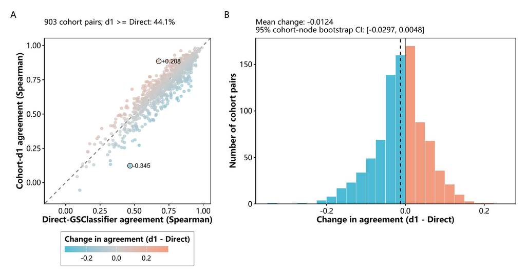

```r
knitr::include_graphics(fig11_jpg)
```

**A 图先看点在对角线的哪一侧。** 横轴为 Direct 的状态距离排序一致性，纵轴为同一队列对在 d1 中的一致性，每个点代表一个队列对。虚线为两者相等的位置；上方表示 d1 更一致，下方表示更不一致。两轴使用相同尺度并覆盖全部观测值，颜色从蓝经灰到橙表示差值由负到正，灰色点接近零差值。黑圈和数值标出最大增幅与最大降幅，具体队列名称见下文。

**B 图看变化幅度与分布。** 横轴是配对差 $\Delta=S^{(d1)}-S^{(Direct)}$，纵轴是各差值区间的队列对数。蓝色柱表示下降，橙色柱表示差值非负，包含恰好为零的比较；零处实线为改善与下降的分界，黑色虚线为平均配对差。图上给出的 95% 区间来自已有的队列节点 bootstrap，描述平均差的不确定性，并非覆盖 95% 队列对的差值范围。队列对共享队列，柱中的比较不能当作相互独立的实验。

**两种表示的总体水平接近，但各队列对的变化方向并不一致。** 正向均值分别为 0.713 与 0.701，d1 不低于 Direct 的队列对占 44.1%。该比例以队列对为分母，包含差值为零的情形，不能换算为“受益患者比例”。最大增幅出现在 SARC/TCGATARGET-SARC 与 UCS/TCGATARGET-UCS，为 0.208；最大降幅出现在 Blood/TCGATARGET-Blood 与 UCS/TCGATARGET-UCS，为 -0.345。相反方向的变化可以相互抵消，所以平均差接近零仍可能伴随具体状态关系的改变。

### 4.8 Figures 12–13：队列对之间的差异

```r
# ==== Figure 12: Direct structural-similarity heatmap (user-adjustable parameters) ====
fig12 <- list(
  # Cohort names are shown once on the rows; columns use the same order.
  width_in = 14,
  height_in = 13,
  base_size = 9,
  tile_line_width = 0.18,
  # Both panels share -1 to 1 so all correlations have a common scale; this supports
  # visible contrast while preserving direct cellwise comparability.
  fill_limits = c(-1, 1),
  fill_midpoint = 0,
  legend_position = "right"
)
p12 <- ggplot2::ggplot(
  structural_direct_heatmap,
  ggplot2::aes(
    x = .data$cohort_a,
    y = .data$cohort_b,
    fill = .data$similarity
  )
) +
  ggplot2::geom_tile(
    color = "white",
    linewidth = fig12$tile_line_width
  ) +
  ggplot2::scale_fill_gradient2(
    low = nature_colors[["blue"]],
    mid = "white",
    high = nature_colors[["red"]],
    midpoint = fig12$fill_midpoint,
    limits = fig12$fill_limits,
    name = "Spearman"
  ) +
  ggplot2::labs(x = "Cohort (row order, top to bottom)", y = "Cohort") +
  ggplot2::coord_fixed() +
  theme_nature_readable(
    base_size = fig12$base_size,
    legend_position = fig12$legend_position
  ) +
  ggplot2::theme(axis.text.x = ggplot2::element_blank(),
    axis.ticks.x = ggplot2::element_blank())

# Readability check: row labels identify both axes because the square matrix
# uses the same cohort order across columns. This avoids overlapping column
# labels while preserving cellwise comparison with Figure 13.
fig12_jpg <- .ae_save_plot(
  p12, "02.03.00. structural-similarity-direct", figure_dir,
  preview_dir, fig12, params$plot_preview_dpi
)
```

```
## Converting page 1 to D:/cache/ccs/_ablation-03/logs/report-previews/02.03.00-structural-reproducibility-20261010221532/02.03.00. structural-similarity-direct.jpg... done!
```

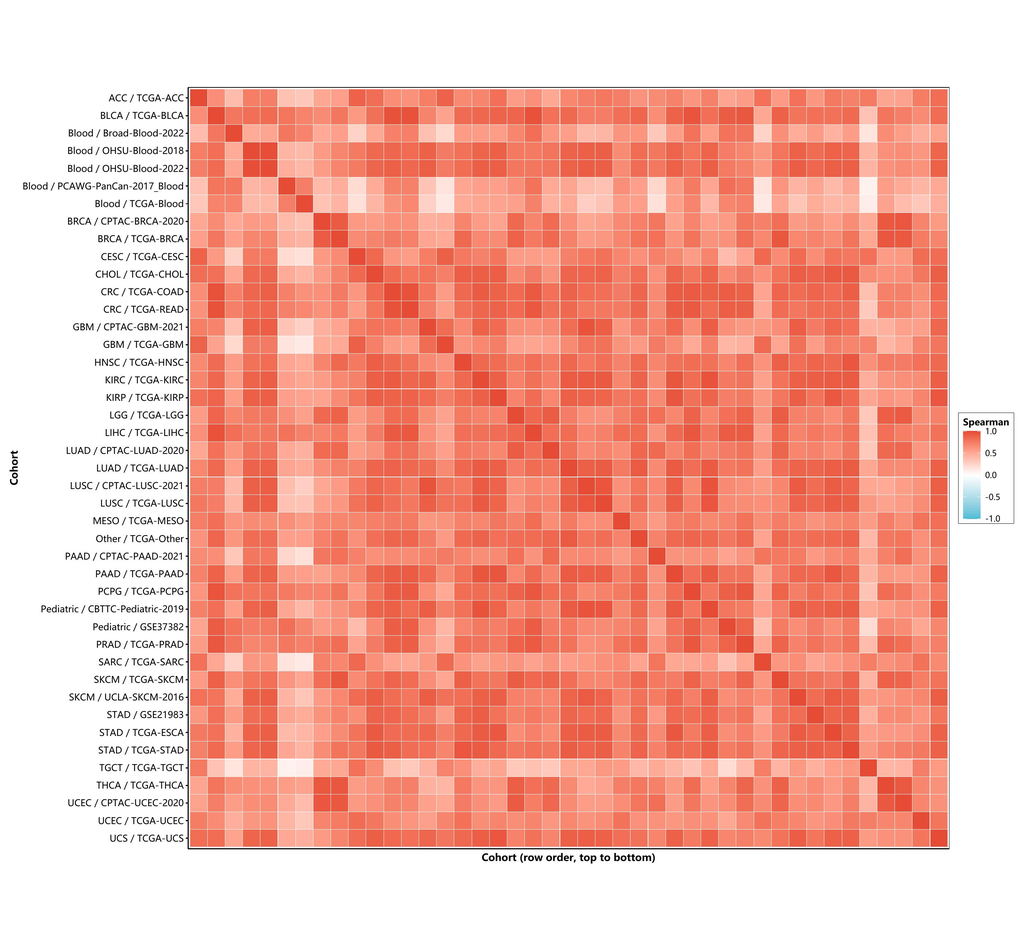

```r
knitr::include_graphics(fig12_jpg)
```

横轴列顺序与左侧队列名从上到下的顺序一致；省略重复的横轴名称，精确队列对可在上方明细表中查询。

Figure 12 的每个非对角格子显示两个队列的基线排序相关。矩阵两半对称，同一队列对只计一次；**对角线的 1 是绘图设定，不属于独立外部验证，也不计入总体均值**。无有效比较的格子保留 NA，空格不代表零相关。红色表示排序更一致，蓝色表示反向关联。颜色仅反映相关系数，不标记癌种分型或单格统计显著性。

Direct 的相关范围为 0.084 至 0.991，可见基线本身已有明显的队列对差异。Figure 13 沿用相同队列顺序和 −1 至 1 色阶，便于逐格比较。两图中相似的红色区域提示可复现程度可能接近，具体变化仍应以对应数值和配对差为准。

```r
# ==== Figure 13: d1 structural-similarity heatmap (user-adjustable parameters) ====
# Reuse the exact Figure 12 dimensions, typography, and color limits so visual
# differences reflect data rather than plotting choices.
fig13 <- fig12
p13 <- ggplot2::ggplot(
  structural_d1_heatmap,
  ggplot2::aes(
    x = .data$cohort_a,
    y = .data$cohort_b,
    fill = .data$similarity
  )
) +
  ggplot2::geom_tile(
    color = "white",
    linewidth = fig13$tile_line_width
  ) +
  ggplot2::scale_fill_gradient2(
    low = nature_colors[["blue"]],
    mid = "white",
    high = nature_colors[["red"]],
    midpoint = fig13$fill_midpoint,
    limits = fig13$fill_limits,
    name = "Spearman"
  ) +
  ggplot2::labs(x = "Cohort (row order, top to bottom)", y = "Cohort") +
  ggplot2::coord_fixed() +
  theme_nature_readable(
    base_size = fig13$base_size,
    legend_position = fig13$legend_position
  ) +
  ggplot2::theme(axis.text.x = ggplot2::element_blank(),
    axis.ticks.x = ggplot2::element_blank())

# Readability check: Figure 13 shares Figure 12's row order, square aspect,
# external legend, and common -1 to 1 scale, enabling cellwise visual
# comparison without rescaling artifacts.
fig13_jpg <- .ae_save_plot(
  p13, "02.03.00. structural-similarity-d1", figure_dir,
  preview_dir, fig13, params$plot_preview_dpi
)
```

```
## Converting page 1 to D:/cache/ccs/_ablation-03/logs/report-previews/02.03.00-structural-reproducibility-20261010221532/02.03.00. structural-similarity-d1.jpg... done!
```

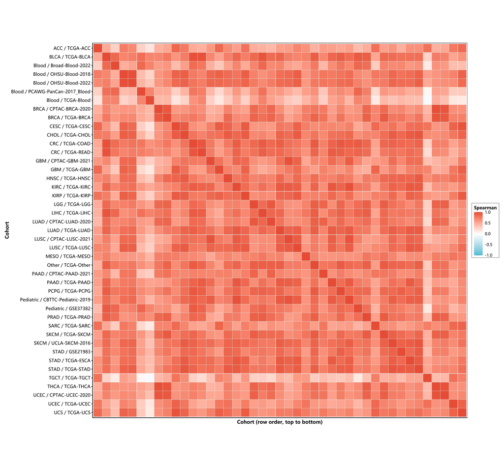

```r
knitr::include_graphics(fig13_jpg)
```

这张图沿用相同的行列顺序；横轴各列仍按左侧队列名从上到下排列。

d1 的相关范围为 -0.055 至 0.983。同一格变得更红，表示两个队列的距离排序在 d1 中更一致，但尚无法确定哪些状态对的距离发生了变化，也不能据此判断某个通路被增强。一行或一列有多处变化时，可核查该共享队列的测量基因、癌种和患者构成。这些格子依赖同一队列，不能作为多次独立支持。极端格子可帮助诊断异质性，机制判断仍需独立验证。

### 4.9 总体区间与同癌种分组比较：为什么按队列节点重采样

图中的 **Same cancer-type group 指队列对两端具有相同的项目 `cancer_type` 分组标签**，汇总多个分组内的比较，并非一个特定癌种，也不要求病理诊断完全相同。例如，当前 `CRC` 合并了 TCGA-COAD 与 TCGA-READ，`STAD` 分组包含 TCGA-ESCA 与 TCGA-STAD；`Blood` 和 `Pediatric` 也是较宽的分组。因此，下文称其为“同癌种分组”，具体队列名单列于组成表。

正向全体 43 个队列形成 903 对比较，包括跨分组的队列对。限制到相同标签后，仅有 11 个分组、26 个队列和 22 对比较；其余 17 个队列所在分组没有第二个可比较队列。这里的队列数是实际参与同分组比较的节点数，不是癌种数，也不是患者数。

```r
# Paired mean changes use the primary structural summary, not the supplementary
# inference table, whose bootstrap seed and interval endpoints differ.
fig_node_summary <- list(
  width_in = 10.5,
  height_in = 4.1,
  base_size = 11,
  point_size = 3,
  interval_line_width = 0.7,
  node_size = 11,
  node_label_size = 3.8,
  edge_label_size = 3.3
)
structural_interval_data <- structural_summary[
  match(c("all_cohort_pairs", "same_cancer_type"), structural_summary$scope),
  , drop = FALSE
]
structural_interval_data$scope_label <- factor(
  paste0(
    c("All cohort pairs", "Same cancer-type group"), "\n",
    structural_interval_data$cohort_count, " cohorts; ",
    structural_interval_data$cohort_pair_count, " pairs"
  ),
  levels = rev(paste0(
    c("All cohort pairs", "Same cancer-type group"), "\n",
    structural_interval_data$cohort_count, " cohorts; ",
    structural_interval_data$cohort_pair_count, " pairs"
  ))
)
# Keep descriptive points even if a subgroup has no estimable interval.
structural_interval_ci <- structural_interval_data[
  structural_interval_data$inference_status == "estimable" &
    is.finite(structural_interval_data$mean_delta_ci_low) &
    is.finite(structural_interval_data$mean_delta_ci_high),
  , drop = FALSE
]
p_node_interval <- ggplot2::ggplot(
  structural_interval_data,
  ggplot2::aes(x = .data$mean_delta, y = .data$scope_label)
) +
  ggplot2::geom_vline(xintercept = 0, linetype = "dashed", color = "grey50") +
  ggplot2::geom_errorbar(
    data = structural_interval_ci,
    ggplot2::aes(
      xmin = .data$mean_delta_ci_low, xmax = .data$mean_delta_ci_high
    ),
    orientation = "y", width = 0.12,
    linewidth = fig_node_summary$interval_line_width,
    color = nature_colors[["navy"]]
  ) +
  ggplot2::geom_point(
    size = fig_node_summary$point_size, color = nature_colors[["navy"]],
    na.rm = TRUE
  ) +
  ggplot2::scale_x_continuous(
    expand = ggplot2::expansion(mult = c(0.12, 0.12))
  ) +
  ggplot2::scale_y_discrete(drop = FALSE, expand = ggplot2::expansion(add = 0.7)) +
  ggplot2::labs(x = "Mean change in agreement (d1 - Direct)", y = NULL) +
  theme_nature_readable(base_size = fig_node_summary$base_size,
    legend_position = "none") +
  ggplot2::theme(panel.border = ggplot2::element_blank(),
    axis.line.y = ggplot2::element_blank(), axis.ticks.y = ggplot2::element_blank())

# Illustrative cohorts A, B and C are not measurements from the experiment.
structural_node_demo <- data.frame(
  cohort = c("A", "B", "C"), x = c(0.15, 0.85, 0.85), y = c(0.5, 0.8, 0.2)
)
structural_edge_demo <- data.frame(
  x = c(0.15, 0.15), y = c(0.5, 0.5),
  xend = c(0.85, 0.85), yend = c(0.8, 0.2),
  label = c("A-B comparison", "A-C comparison"),
  label_x = c(0.5, 0.5), label_y = c(0.73, 0.27)
)
p_node_dependence <- ggplot2::ggplot() +
  ggplot2::geom_segment(
    data = structural_edge_demo,
    ggplot2::aes(x = .data$x, y = .data$y,
      xend = .data$xend, yend = .data$yend),
    linewidth = 0.8, color = "grey55"
  ) +
  ggplot2::geom_label(
    data = structural_edge_demo,
    ggplot2::aes(x = .data$label_x, y = .data$label_y, label = .data$label),
    size = fig_node_summary$edge_label_size, label.size = NA,
    fill = "white"
  ) +
  ggplot2::geom_point(
    data = structural_node_demo,
    ggplot2::aes(x = .data$x, y = .data$y, fill = .data$cohort == "A"),
    shape = 21, size = fig_node_summary$node_size, stroke = 0.6,
    color = nature_colors[["navy"]]
  ) +
  ggplot2::scale_fill_manual(
    values = c("TRUE" = nature_colors[["orange"]], "FALSE" = "white"),
    guide = "none"
  ) +
  ggplot2::geom_text(
    data = structural_node_demo,
    ggplot2::aes(x = .data$x, y = .data$y, label = .data$cohort),
    size = fig_node_summary$node_label_size, fontface = "bold"
  ) +
  ggplot2::annotate("text", x = 0.5, y = 0.02,
    label = "Shared cohort A", size = fig_node_summary$node_label_size) +
  ggplot2::coord_fixed(xlim = c(0, 1), ylim = c(-0.08, 1), expand = FALSE) +
  ggplot2::theme_void(base_size = fig_node_summary$base_size,
    base_family = getOption("bensz.base_family", "sans")) +
  ggplot2::theme(plot.margin = ggplot2::margin(10, 10, 10, 10))
p_node_summary <- patchwork::wrap_plots(
  p_node_interval, p_node_dependence, nrow = 1, widths = c(1.6, 1)
) + patchwork::plot_annotation(tag_levels = "A")
fig_node_summary_jpg <- .ae_save_plot(
  p_node_summary, "02.03.00. structural-node-summary", figure_dir,
  preview_dir, fig_node_summary, params$plot_preview_dpi
)
```

```
## Converting page 1 to D:/cache/ccs/_ablation-03/logs/report-previews/02.03.00-structural-reproducibility-20261010221532/02.03.00. structural-node-summary.jpg... done!
```

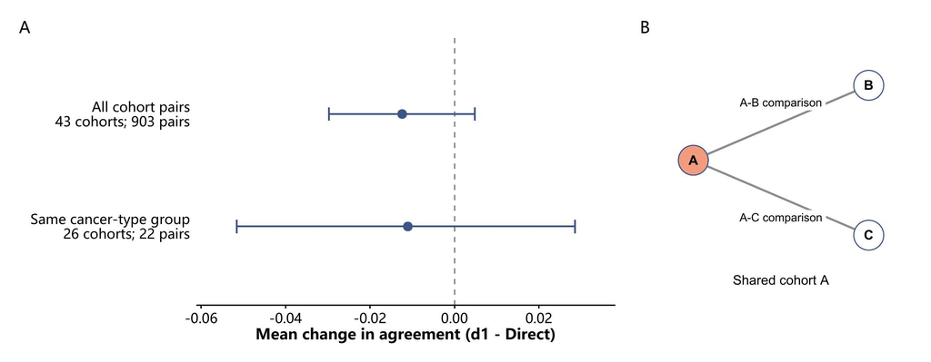

```r
knitr::include_graphics(fig_node_summary_jpg)
```

**A 图比较正向全体队列对与同癌种分组子集的平均变化。** 点为平均 d1−Direct，横线为正式结构摘要中的 95% 队列节点 bootstrap 区间，虚线表示零差。两行共用横轴，左侧标出实际队列数和队列对数；没有可估计区间时只保留可用的点估计，完整状态见下表。当前两组点估计接近，同癌种分组子集的区间更宽，两者均跨零。这些区间分别描述各自平均差的不确定性，未检验两组效应之差，也不证明等价或无损。

**B 图说明两条比较为什么相互依赖。** A、B、C 是示意队列，A–B 与 A–C 共享队列 A。若 A 的状态测量发生偏移，两条边都可能随之改变。因此，重采样以队列节点为单位，并同步改变与该节点相连的比较权重，不能把这些队列对独立抽取。节点颜色只突出共享的 A，不表示实验效应或重采样频次。

```r
render_dt(
  structural_summary[, c(
    "scope", "cohort_count", "cohort_pair_count",
    "mean_direct_similarity", "median_direct_similarity",
    "mean_d1_similarity", "median_d1_similarity", "mean_delta",
    "median_delta", "fraction_d1_ge_direct", "mean_delta_ci_low",
    "mean_delta_ci_high", "inference_method", "inference_status",
    "min_inference_cohorts", "min_inference_pairs", "p_value_reason"
  )],
  pageLength = 5
)
```

|  | scope | cohort_count | cohort_pair_count | mean_direct_similarity | median_direct_similarity | mean_d1_similarity | median_d1_similarity | mean_delta | median_delta | fraction_d1_ge_direct | mean_delta_ci_low | mean_delta_ci_high | inference_method | inference_status | min_inference_cohorts | min_inference_pairs | p_value_reason |
| --- | --- | --- | --- | --- | --- | --- | --- | --- | --- | --- | --- | --- | --- | --- | --- | --- | --- |
| 1 | all_cohort_pairs | 43 | 903 | 0.713317342134329 | 0.737154150197628 | 0.700913949548934 | 0.724901185770751 | -0.0124033925853946 | -0.00737812911725955 | 0.440753045404208 | -0.0297496541060566 | 0.00477633620899478 | cohort_node_bootstrap | estimable | 4 | 3 | Cohort-pair rows share cohort nodes; a paired Wilcoxon test would treat dependent dyads as independent. |
| 2 | same_cancer_type | 26 | 22 | 0.728889687387711 | 0.783530961791831 | 0.717828482452988 | 0.803359683794466 | -0.0110612049347227 | -0.0108695652173914 | 0.409090909090909 | -0.0515494764579432 | 0.0284963862224732 | cohort_node_bootstrap | estimable | 4 | 3 | Cohort-pair rows share cohort nodes; a paired Wilcoxon test would treat dependent dyads as independent. |

正向全体队列对的平均差为 -0.0124，95% 区间为 [-0.0297, 0.0048]。在当前推断条件下，变化量级较小，区间仍同时包含下降和改善。**平均变化的方向尚不明确。只有预先确定科学上可接受的损失界值，才能进一步判断变化是否“足够小”；区间跨零本身不足以支持“等价”或“无损”。**

以三个队列为例，A–B 和 A–C 都涉及 A。如果 A 的状态测量偏移，两项比较可能同时变化；独立抽取队列对会破坏这种依赖。当前正向 43 个有效队列形成 903 对比较，比较次数因此不能视为独立队列数。

每次 bootstrap 有放回抽取同样数量的队列节点。若节点 $a,b$ 分别抽中 $N_a^*,N_b^*$ 次，该条既有边的权重就是两端次数之积：

$$\widehat\Delta^*
=\frac{\sum_{(a,b)\in\mathcal P}N_a^*N_b^*\Delta_{ab}}
{\sum_{(a,b)\in\mathcal P}N_a^*N_b^*}.$$

任一端点未抽中的边不参与计算，无有效边的重复被丢弃，重复抽到同一队列也不新增自我比较。正式结构分析设置 2000 次重复，以有效均值分布的 2.5% 和 97.5% 分位数给出区间。**重采样仅改变节点组成和边的权重，患者、状态质心和 bank 均保持不变。** 该区间反映固定表示、分组及现有目标队列网络下的队列组成不确定性，未涵盖患者测量、训练、模块重选及未来任意队列的全部波动。

同癌种分组子集用于考察相同项目标签下，不同队列的状态关系是否相似；组内的病理类型、平台、疾病阶段和取样构成仍未控制。当前正向有 22 对比较，达到预设推断门槛，平均差为 -0.0111，节点 bootstrap 区间为 [-0.0515, 0.0285]。该子集的点估计也较小，区间更宽，平均变化方向尚不明确。全体与同癌种分组子集之间未进行正式交互检验，二者结果的差异不能归因于癌种混杂已被消除。

**同分组平均差仍按队列对等权，而非癌种分组等权。** 下表的权重占比为该分组的队列对数除以全部同分组队列对数。当前贡献最多的是 Blood，有 5 个队列、10 对比较，占 45.5%。因此，这一均值对队列较多、形成比较较多的分组更敏感，不能解释为各癌种平均贡献相同。

```r
structural_same_group_table <- structural_same_group_composition
structural_same_group_table$pair_weight_share <- fmt_pct(
  structural_same_group_table$pair_weight_share
)
render_dt(structural_same_group_table, pageLength = 12L)
```

|  | cancer_type_group | cohort_count | cohort_pair_count | pair_weight_share | cohorts |
| --- | --- | --- | --- | --- | --- |
| Blood | Blood | 5 | 10 | 45.5% | Blood/Broad-Blood-2022; Blood/OHSU-Blood-2018; Blood/OHSU-Blood-2022; Blood/PCAWG-PanCan-2017_Blood; Blood/TCGATARGET-Blood |
| STAD | STAD | 3 | 3 | 13.6% | STAD/GSE21983; STAD/TCGATARGET-ESCA; STAD/TCGATARGET-STAD |
| BRCA | BRCA | 2 | 1 | 4.5% | BRCA/CPTAC-BRCA-2020; BRCA/TCGATARGET-BRCA |
| CRC | CRC | 2 | 1 | 4.5% | CRC/TCGATARGET-COAD; CRC/TCGATARGET-READ |
| GBM | GBM | 2 | 1 | 4.5% | GBM/CPTAC-GBM-2021; GBM/TCGATARGET-GBM |
| LUAD | LUAD | 2 | 1 | 4.5% | LUAD/CPTAC-LUAD-2020; LUAD/TCGATARGET-LUAD |
| LUSC | LUSC | 2 | 1 | 4.5% | LUSC/CPTAC-LUSC-2021; LUSC/TCGATARGET-LUSC |
| PAAD | PAAD | 2 | 1 | 4.5% | PAAD/CPTAC-PAAD-2021; PAAD/TCGATARGET-PAAD |
| Pediatric | Pediatric | 2 | 1 | 4.5% | Pediatric/CBTTC-Pediatric-2019; Pediatric/GSE37382 |
| SKCM | SKCM | 2 | 1 | 4.5% | SKCM/TCGATARGET-SKCM; SKCM/UCLA-SKCM-2016 |

[output cut: 1 more lines]

组成表中的 `cancer_type_group` 是项目分组标签，`cohort_count` 与 `cohort_pair_count` 分别为该组实际参与比较的队列数与队列对数，`pair_weight_share` 为其在同分组均值中的权重占比，`cohorts` 列出原队列标识。表中保留原名称，便于识别合并在同一标签下的不同病理类别。

下表读取 `statistical_inference$structural`，列出节点层推断的均值、辅助中位数及“不低于 Direct 的队列对比例”，便于与总体结果核对。两套区间均采用节点 percentile bootstrap，但正式结构摘要与补充推断使用不同的固定种子，Monte Carlo 区间端点可能略有差别。正文主效应统一引用上方结构摘要，两套区间分别呈现，不混用端点。

```r
render_dt(statistical_inference$structural, pageLength = 4L)
```

|  | direction | scope | mean_delta | mean_ci_low | mean_ci_high | median_delta | median_ci_low | median_ci_high | fraction_d1_ge_direct | fraction_ci_low | fraction_ci_high | p_value | n_cohort | n_pairs | min_node_degree | resamples | valid_resamples | null_simulation_coverage | seed | unit | ci_method | p_method | status | reason | p_value_adj | multiplicity_family |
| --- | --- | --- | --- | --- | --- | --- | --- | --- | --- | --- | --- | --- | --- | --- | --- | --- | --- | --- | --- | --- | --- | --- | --- | --- | --- | --- |
| 1 | reference_bank_to_external_targets | all_cohort_pairs | -0.01240339258539461 | -0.03085940556066551 | 0.004611763259383546 | -0.00737812911725955 | -0.0234519104084321 | 0.00606060606060599 | 0.4407530454042082 | 0.3355989509854321 | 0.5490713785630078 | 0.1662902894813189 | 43 | 903 | 42 | 2000 | 2000 | 0.94 | 20260925 | shared_cohort_node | cohort_node_percentile_bootstrap | node_jackknife_t | estimable |  | 0.6651611579252754 | four_direction_scope_mean_deltas |
| 2 | reference_bank_to_external_targets | same_cancer_type | -0.01106120493472272 | -0.04943642106685574 | 0.02663950040178321 | -0.01086956521739143 | -0.0395256916996047 | 0.0155467720685112 | 0.4090909090909091 | 0.06890804597701149 | 0.772763929618768 |  | 26 | 22 | 1 | 2000 | 2000 |  | 20260926 | shared_cohort_node | cohort_node_percentile_bootstrap | not_estimable | not_estimable | sparse_node_network_or_low_valid_bootstrap_rate |  | four_direction_scope_mean_deltas |
| 3 | external_bank_to_reference_targets | all_cohort_pairs | 0.00210504113278812 | -0.01623258156348999 | 0.01951338895258066 | 0.00566534914360994 | -0.00777338603425559 | 0.0183135704874835 | 0.5266423717127943 | 0.465065388565782 | 0.5872852922902181 | 0.8143724500511822 | 143 | 10153 | 142 | 2000 | 2000 | 0.9433333333333334 | 20260927 | shared_cohort_node | cohort_node_percentile_bootstrap | node_jackknife_t | estimable |  | 1 | four_direction_scope_mean_deltas |
| 4 | external_bank_to_reference_targets | same_cancer_type | -0.003476518205787827 | -0.03476565319982588 | 0.02648357913036687 | 0.0104084321475626 | -0.007776679841897255 | 0.0283267457180502 | 0.5476363636363636 | 0.4581004771042091 | 0.6393158935900959 |  | 137 | 1375 | 1 | 2000 | 2000 |  | 20260928 | shared_cohort_node | cohort_node_percentile_bootstrap | not_estimable | not_estimable | sparse_node_network_or_low_valid_bootstrap_rate |  | four_direction_scope_mean_deltas |

**零假设检验对队列网络的要求比区间估计更高。** 上方结构摘要在至少四个节点、三条有效边时给出区间；补充均值检验还要求至少 12 个节点、每个节点至少三条边、有足够有效重采样，并通过当前网络上节点效应加边噪声的覆盖模拟。满足这些条件后，才使用删一节点 jackknife 标准误进行均值是否为零的双侧检验，并在正反方向 × 全体／同癌种分组的固定四项族内作 Holm 校正。

本次两个全体网络均满足检验条件，Holm 校正 P 值分别为 0.665 与 1，尚无明确证据表明平均差偏离零。两个同癌种分组网络中，部分节点参与的比较次数不足，P 值保留 NA；**NA 表示未满足检验条件，不能解释为“不显著”或“没有差异”**。表中 `status` 描述检验是否满足条件；仍可计算的描述性均值和条件区间继续保留，不以零替代。

### 4.10 Figure 14 与 matched-bank：匹配模块数量和组织组成后的差异

**这个实验固定评价患者，只更换组成 d1 的模型模块，检查结果对模块选择有多敏感。** Reference 与 external 是两套已有的模型库，分别含 150 和 43 个模块。一个模块是一个已经训练好的队列模型，可以输出若干列患者表示；模块数相同并不保证输出列数相同。完整库的规模和组织覆盖不同，因此从两侧各选出模块数量与组织配额一致的子库，再分别评价。

**先确定每个组织两侧各选多少模块。** 只使用两个模型库共有的 16 个组织；对每个组织，取两侧可用模块数的较小值作为共同配额。下表列出全部配额，最后一列相加为每侧每轮的 22 个模块。这里匹配的是项目中的组织标签及模块数量，不要求两侧选到同一个模型。

| 组织标签 | reference 可用模块 | external 可用模块 | 每侧每轮选取 |
| --- | --- | --- | --- |
| ACC | 8 | 1 | 1 |
| BLCA | 2 | 1 | 1 |
| BRCA | 20 | 2 | 2 |
| CHOL | 1 | 1 | 1 |
| CRC | 41 | 2 | 2 |
| HNSC | 1 | 1 | 1 |
| KIRC | 11 | 1 | 1 |
| LGG | 3 | 1 | 1 |
| LIHC | 1 | 1 | 1 |
| LUAD | 3 | 2 | 2 |
| LUSC | 1 | 2 | 1 |
| PAAD | 13 | 2 | 2 |
| PRAD | 16 | 1 | 1 |
| SARC | 2 | 1 | 1 |
| STAD | 20 | 3 | 3 |
| UCEC | 1 | 2 | 1 |

例如，BRCA 在 reference 库有 20 个模块，external 库有 2 个，所以两侧每轮各选 2 个。Reference 侧有多种选择，external 侧则必须把这一组织的全部模块选入。每轮在各组织内部无放回抽取；下一轮重新从原模块池抽，因此可以再次选到之前的成员或完整组合。抽取沿用已经训练好的模型，不重新训练，也不重抽患者。

**再把选出的模块用于固定的评价患者。** A 图使用 reference 模块评价 external 患者，B 图使用 external 模块评价 reference 患者；每轮的方向与评价规模如下。

| 面板 | 模块来源 | 评价患者 | 匹配模块数 | 完整库模块数 | 固定患者数 | 评价队列数 | 有效队列对数 |
| --- | --- | --- | --- | --- | --- | --- | --- |
| A | reference | external | 22 | 150 | 14060 | 43 | 903 |
| B | external | reference | 22 | 43 | 24487 | 143 | 10153 |

**共有组织限制只作用于模型模块，评价患者没有随之缩减成这些组织。** 同一方向内，患者名单、gene signature 高低状态分组、Direct 表示和比较门槛均保持固定；每轮只更换 d1 的模块成员，取出对应的模型输出列，沿用拟合侧标尺并按模块宽度平衡权重。A、B 评价的人群不同，因此不能把两侧点的位置直接当作两个模型库的优劣比较。匹配模块数量与组织配额后，两侧的训练人数、输出列数、特征选择及模型质量仍可能不同。

**图上的一个点怎样得到？** 以 A 图的一轮为例：从 reference 库挑出 22 个模块，用对应的 d1 输出计算各 external 队列中生物状态的质心与状态间距离。对每个有效队列对，分别得到 Direct 与 d1 的状态距离排序 Spearman 一致性，再计算 d1−Direct；最后对本方向的 903 个队列对等权取平均，得到一个蓝点。B 图同样计算，只是换成 external 模块及 reference 患者，并对 10153 个队列对取平均。Figure 11 的一个点是一个队列对，Figure 14 的一个点是一整套模块组合的总体评价。

这样的抽取重复 20 轮，两侧各有同样多的匹配抽样点。完整库另外评价一次，使用各自全部 150 或 43 个模块，沿用同方向的患者与 Direct 基线，画成下方的空心菱形。它不受匹配子库的模块配额限制。横轴零线表示两种表示的平均一致性相同，左侧表示 d1 较低，右侧表示 d1 较高；图中不绘制置信区间。

```r
# ==== Figure 14: Reciprocal matched-bank sensitivity (user-adjustable parameters) ====
fig14 <- list(
  width_in = 12.8,
  height_in = 4.8,
  base_size = 11,
  point_size = 2.8,
  point_alpha = 0.8,
  jitter_height = 0.22,
  jitter_seed = 20260912L,
  full_point_size = 3.8,
  zero_line_width = 0.55,
  x_padding = 0.12
)
# Identity is the complete selected module set, never a rounded effect value.
fig14_bank_keys <- function(bank_role) {
  selected <- structural_matched_design[
    structural_matched_design$bank_role == bank_role, , drop = FALSE
  ]
  banks <- split(selected, selected$repeat_id)
  data.frame(
    repeat_id = as.integer(names(banks)),
    bank_key = vapply(banks, function(bank) {
      paste(sort(bank$module_id), collapse = "\n")
    }, character(1)),
    stringsAsFactors = FALSE
  )
}
fig14_reference <- structural_matched_all[
  structural_matched_all$bank_role == "reference", , drop = FALSE
]
fig14_external <- structural_matched_all[
  structural_matched_all$bank_role == "external", , drop = FALSE
]
fig14_reference_keys <- fig14_bank_keys("reference")
fig14_external_keys <- fig14_bank_keys("external")
stopifnot(setequal(fig14_reference$repeat_id, fig14_reference_keys$repeat_id),
  setequal(fig14_external$repeat_id, fig14_external_keys$repeat_id),
  !anyDuplicated(fig14_reference$repeat_id), !anyDuplicated(fig14_external$repeat_id))
fig14_external$bank_key <- fig14_external_keys$bank_key[
  match(fig14_external$repeat_id, fig14_external_keys$repeat_id)
]
fig14_external_design <- structural_matched_design[
  structural_matched_design$bank_role == "external", , drop = FALSE
]
fig14_variable_tissues <- names(Filter(function(part) {
  sets <- vapply(split(part, part$repeat_id), function(bank) {
    paste(sort(bank$module_id), collapse = "\n")
  }, character(1))
  length(unique(sets)) > 1L
}, split(fig14_external_design, fig14_external_design$tissue)))
fig14_external_groups <- do.call(rbind, lapply(
  split(fig14_external, fig14_external$bank_key), function(part) {
    # Repeated draws of one fixed bank must reproduce the same statistic.
    stopifnot(all(is.finite(part$mean_delta)),
      diff(range(part$mean_delta)) < 1e-12)
    members <- fig14_external_design[
      fig14_external_design$repeat_id == part$repeat_id[1L] &
        fig14_external_design$tissue %in% fig14_variable_tissues,
      , drop = FALSE
    ]
    member_labels <- vapply(split(members, members$tissue), function(group) {
      sources <- sub("^[^|]+\\|", "", group$module_id)
      sources <- sub("-.*$", "", sources)
      sources[sources == "TCGATARGET"] <- "TCGA"
      paste0(group$tissue[1L], ": ", paste(sort(sources), collapse = "+"))
    }, character(1))
    data.frame(
      member_label = paste(member_labels, collapse = " / "),
      selected_variable_modules = paste(sort(members$module_id), collapse = "; "),
      draw_count = nrow(part),
      repeat_ids = paste(sort(part$repeat_id), collapse = ", "),
      mean_delta = part$mean_delta[1L],
      stringsAsFactors = FALSE
    )
  }
))
fig14_external_groups <- fig14_external_groups[
  order(-fig14_external_groups$mean_delta), , drop = FALSE
]
rownames(fig14_external_groups) <- NULL
stopifnot(sum(fig14_external_groups$draw_count) == nrow(fig14_external))
fig14_x_range <- range(c(structural_matched_all$mean_delta,
  structural_forward_all$mean_delta, structural_reverse_all$mean_delta, 0))
fig14_x_limits <- fig14_x_range + c(-1, 1) * diff(fig14_x_range) * fig14$x_padding
fig14_axis <- function() {
  list(
    ggplot2::geom_vline(xintercept = 0, linetype = "dashed",
      linewidth = fig14$zero_line_width, color = "grey55"),
    ggplot2::scale_x_continuous(limits = fig14_x_limits,
      breaks = pretty(fig14_x_limits, n = 4L),
      labels = function(x) sprintf("%.3f", x), expand = c(0, 0)),
    ggplot2::labs(x = "Mean change in agreement (d1 - Direct)", y = NULL),
    theme_nature_readable(base_size = fig14$base_size, legend_position = "none"),
    ggplot2::theme(panel.border = ggplot2::element_blank(),
      axis.line.y = ggplot2::element_blank(),
      axis.ticks.y = ggplot2::element_blank(),
      plot.title = ggplot2::element_text(size = fig14$base_size,
        face = "bold", hjust = 0),
      plot.subtitle = ggplot2::element_text(size = fig14$base_size - 1,
        hjust = 0))
  )
}
fig14_reference_labels <- c(
  paste0("Matched banks\n", structural_matched_modules, " modules"),
  paste0("Full bank\n", structural_reference_modules, " modules")
)
fig14_reference$row_label <- factor(fig14_reference_labels[1L],
  levels = rev(fig14_reference_labels))
fig14_reference_full <- data.frame(
  mean_delta = structural_forward_all$mean_delta,
  row_label = factor(fig14_reference_labels[2L], levels = rev(fig14_reference_labels))
)
p14_reference <- ggplot2::ggplot(fig14_reference,
  ggplot2::aes(x = .data$mean_delta, y = .data$row_label)) +
  fig14_axis() +
  ggplot2::geom_jitter(
    position = ggplot2::position_jitter(width = 0, height = fig14$jitter_height,
      seed = fig14$jitter_seed),
    size = fig14$point_size, alpha = fig14$point_alpha,
    color = nature_colors[["blue"]]
  ) +
  ggplot2::geom_point(data = fig14_reference_full, shape = 23,
    size = fig14$full_point_size, fill = "white", color = "black", stroke = 0.9) +
  ggplot2::scale_y_discrete(limits = rev(fig14_reference_labels),
    expand = ggplot2::expansion(add = 0.6)) +
  ggplot2::labs(title = "Reference modules on external targets",
    subtitle = paste0(nrow(fig14_reference), " draws; ",
      length(unique(fig14_reference_keys$bank_key)), " distinct banks\n",
      "Each point is one draw"))
fig14_external_labels <- c(
  paste0("Matched banks\n", structural_matched_modules, " modules"),
  paste0("Full bank\n", structural_external_modules, " modules")
)
fig14_external$row_label <- factor(fig14_external_labels[1L],
  levels = rev(fig14_external_labels))
fig14_external_full <- data.frame(
  mean_delta = structural_reverse_all$mean_delta,
  row_label = factor(fig14_external_labels[2L], levels = rev(fig14_external_labels))
)
p14_external <- ggplot2::ggplot(fig14_external,
  ggplot2::aes(x = .data$mean_delta, y = .data$row_label)) +
  fig14_axis() +
  ggplot2::geom_jitter(
    position = ggplot2::position_jitter(width = 0, height = fig14$jitter_height,
      seed = fig14$jitter_seed),
    size = fig14$point_size, alpha = fig14$point_alpha,
    color = nature_colors[["orange"]]
  ) +
  ggplot2::geom_point(data = fig14_external_full, shape = 23,
    size = fig14$full_point_size, fill = "white", color = "black", stroke = 0.9) +
  ggplot2::scale_y_discrete(limits = rev(fig14_external_labels),
    expand = ggplot2::expansion(add = 0.6)) +
  ggplot2::labs(title = "External modules on reference targets",
    subtitle = paste0(nrow(fig14_external), " draws; ",
      nrow(fig14_external_groups), " distinct banks\n",
      "Draw counts (left to right): ",
      paste(rev(fig14_external_groups$draw_count), collapse = ", ")))
p14 <- patchwork::wrap_plots(p14_reference, p14_external, nrow = 1) +
  patchwork::plot_annotation(tag_levels = "A")

fig14_jpg <- .ae_save_plot(
  p14, "02.03.00. structural-matched-bank-sensitivity", figure_dir,
  preview_dir, fig14, params$plot_preview_dpi
)
```

```
## Converting page 1 to D:/cache/ccs/_ablation-03/logs/report-previews/02.03.00-structural-reproducibility-20261010221532/02.03.00. structural-matched-bank-sensitivity.jpg... done!
```

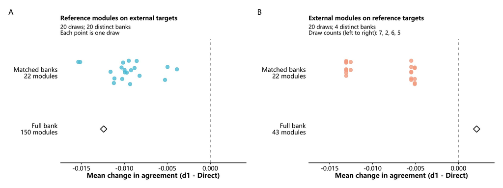

```r
knitr::include_graphics(fig14_jpg)
```

**A 图的每个蓝点代表一次 reference 匹配抽样。** 本次 20 次抽样得到 20 套不同模块组合，每套使用 22 个模块。两图的点都仅沿纵向轻微错开，以减少重叠；横向位置始终是原始效应值，纵向位置没有统计含义。下方空心菱形为完整 150 模块库的结果。

**B 图的每个橙点也代表一次匹配抽样。** External 库在大多数共有组织中的可用模块数恰好等于配额，必须全部选入；只有 LUSC、UCEC 各有二选一的空间。按配额可形成的组合总数为 4，本次 20 次抽样实际覆盖了其中 4 套，因此这些点集中在相应的横坐标位置。从左到右，各组合分别出现 7、2、6、5 次，图中也注明了这些次数。重复抽到同一组合会得到相同结果，这些点的多少表示抽中频率，不能当作新增独立实验。下方空心菱形为完整 43 模块库的结果，上方匹配组合每套使用 22 个模块。

本次较接近零的两套组合使用 TCGA-LUSC，较负的两套组合使用 CPTAC-LUSC；UCEC 的选择解释了各簇内的两个数值。这里描述的是固定患者、其他模块及分析规则下的组合敏感性，不能外推为两类患者或某种平台具有普遍优势。下表保留原模块标识、重复编号和已有平均差，便于逐行核对。

```r
render_dt(fig14_external_groups[, c(
  "selected_variable_modules", "draw_count", "repeat_ids", "mean_delta"
)], pageLength = 6L)
```

|  | selected_variable_modules | draw_count | repeat_ids | mean_delta |
| --- | --- | --- | --- | --- |
| 1 | Undefined\|TCGATARGET-LUSC; Undefined\|TCGATARGET-UCEC | 5 | 3, 11, 13, 14, 20 | -0.00508893952698897 |
| 2 | Undefined\|CPTAC-UCEC-2020; Undefined\|TCGATARGET-LUSC | 6 | 4, 6, 7, 8, 12, 17 | -0.00550406591177461 |
| 3 | Undefined\|CPTAC-LUSC-2021; Undefined\|TCGATARGET-UCEC | 2 | 9, 18 | -0.0125431575735934 |
| 4 | Undefined\|CPTAC-LUSC-2021; Undefined\|CPTAC-UCEC-2020 | 7 | 1, 2, 5, 10, 15, 16, 19 | -0.0130716162787587 |

**匹配模块数与组织配额后，两个方向的全部重复设计均呈小幅负差。** 正向范围为 -0.0154 至 -0.0039，反向为 -0.0131 至 -0.0051，均低于零。B 图完整库菱形位于零右侧，对应平均差 0.0021；使用全部 external 模块时，d1 的平均一致性略高于 Direct，但这一微小正差在所有匹配设计中均转为负差，尚无稳定反向优势的证据。模块数量、共有组织限制与成员选择同时改变，本分析未分离各自影响，负差也不能单独归因于模块数减少。

```r
render_dt(
  structural_matched_summary[, c(
    "direction", "scope", "repeat_count", "bank_module_count",
    "mean_delta_median", "mean_delta_min", "mean_delta_max",
    "mean_direct_similarity_median", "mean_d1_similarity_median",
    "fraction_d1_ge_direct_median", "range_interpretation"
  )],
  pageLength = 4L
)
```

|  | direction | scope | repeat_count | bank_module_count | mean_delta_median | mean_delta_min | mean_delta_max | mean_direct_similarity_median | mean_d1_similarity_median | fraction_d1_ge_direct_median | range_interpretation |
| --- | --- | --- | --- | --- | --- | --- | --- | --- | --- | --- | --- |
| 1 | external_bank_to_reference_targets | all_cohort_pairs | 20 | 22 | -0.00550406591177461 | -0.0130716162787587 | -0.00508893952698897 | 0.579842719992489 | 0.574338654080715 | 0.49157884369152 | design_sensitivity_not_confidence_interval |
| 2 | external_bank_to_reference_targets | same_cancer_type | 20 | 22 | -0.0120462676950813 | -0.0245358516640951 | -0.0108629947057738 | 0.610418690643017 | 0.598372422947935 | 0.495272727272727 | design_sensitivity_not_confidence_interval |
| 3 | reference_bank_to_external_targets | all_cohort_pairs | 20 | 22 | -0.00981817306387579 | -0.0153543232410775 | -0.0038803461452602 | 0.713317342134329 | 0.703499169070453 | 0.452380952380952 | design_sensitivity_not_confidence_interval |
| 4 | reference_bank_to_external_targets | same_cancer_type | 20 | 22 | -0.00764762246975687 | -0.0227512276919392 | 0.0268714816145646 | 0.728889687387711 | 0.721242064917954 | 0.431818181818182 | design_sensitivity_not_confidence_interval |

匹配设计的正向中位差为 -0.0098，反向为 -0.0055。对当前患者和这批有限的固定模块组合，**尚未观察到在不同模块组成下均成立的平均优势**。正向同癌种分组子集的设计范围可跨零，所以全体队列对的负差结论不能推广到所有比较范围，需按表中 `scope` 分别解读。

下表列出重复设计的 2.5%—97.5% 分位范围。相比最小—最大范围，它较少受端点影响，仍仅描述这 20 次设计的分布。各次设计共享模块和目标患者，没有新增队列，也不提供人群层面的 P 值。**这里的 2.5%—97.5% 分位范围仍是设计敏感性的概括，不能解释为 95% 置信区间**。

```r
render_dt(statistical_inference$matched_bank, pageLength = 4L)
```

|  | direction | scope | design_median | design_q025 | design_q975 | n_design | unit | method | condition | p_value | reason |
| --- | --- | --- | --- | --- | --- | --- | --- | --- | --- | --- | --- |
| external_bank_to_reference_targets.all_cohort_pairs | external_bank_to_reference_targets | all_cohort_pairs | -0.00550406591177461 | -0.0130716162787587 | -0.00508893952698897 | 20 | matched_bank_design_repeat | empirical_design_distribution | frozen_patients_and_module_pool |  | overlapping_modules_are_not_independent_new_cohorts |
| reference_bank_to_external_targets.all_cohort_pairs | reference_bank_to_external_targets | all_cohort_pairs | -0.009818173063875796 | -0.01525071238165272 | -0.004400271675296955 | 20 | matched_bank_design_repeat | empirical_design_distribution | frozen_patients_and_module_pool |  | overlapping_modules_are_not_independent_new_cohorts |
| external_bank_to_reference_targets.same_cancer_type | external_bank_to_reference_targets | same_cancer_type | -0.0120462676950813 | -0.0245358516640951 | -0.0108629947057738 | 20 | matched_bank_design_repeat | empirical_design_distribution | frozen_patients_and_module_pool |  | overlapping_modules_are_not_independent_new_cohorts |
| reference_bank_to_external_targets.same_cancer_type | reference_bank_to_external_targets | same_cancer_type | -0.00764762246975687 | -0.02000613845969579 | 0.02364564618517184 | 20 | matched_bank_design_repeat | empirical_design_distribution | frozen_patients_and_module_pool |  | overlapping_modules_are_not_independent_new_cohorts |

### 4.11 当前结论与后续验证

预设高低状态在两种表示中均有跨队列距离排序关联。完整库下的平均配对变化方向尚不明确，各队列对仍有升降；匹配模块数与组织后，全体比较呈小幅负差。原有状态关系是否逐一保留、各癌种内的状态是否均可区分，以及排序一致性能否满足具体科研用途，都需要进一步检验。

| 进一步希望判断什么 | 应固定什么、改变什么 | 怎样的结果更支持该判断 |
| --- | --- | --- |
| d1 是否沿用了 Direct 的具体状态关系 | 固定状态名单与患者，在每个队列内直接比较两臂的状态距离排序，并在独立队列重复；如关心绝对分离，再预设距离与组内散布终点 | 具体状态对排序及预设分离指标稳定，才补足“跨队列都可复现”之外的原关系证据 |
| 同名高低状态是否具有独立生物意义 | 用病理、蛋白或其它独立测量定义状态；固定癌种并控制平台组成，在外部队列重复 | 独立状态定义下仍有跨队列关联与可接受的配对变化，更支持结果超出同源表达分组 |
| 小幅负差是否可接受 | 查看新验证数据前，按预设用途确定非劣效界值 $\varepsilon$，并固定人群、模块设计与终点 | 平均差区间下界高于 $-\varepsilon$ 才支持相应用途的非劣效；等价性另需整个区间落入预设双侧范围 |
| 模块数、组织或成员选择分别影响多少 | 固定目标与组织配额，预先设定模块数网格及成员抽样；另固定模块数改变组织组成，使用独立验收队列 | 受控变化在独立队列中重复，才有助于区分预算、来源和成员敏感性；本次匹配设计不能单独归因 |

上述设计尚未执行。当前分析以表达 gene signature 定义状态，再用同源表达派生的表示计算距离，所得生物线索仍需独立测量验证。高低尾部取样也未覆盖中间状态、连续梯度或组内稀有亚群，这些任务需要在质心关系之外单独评估。

### 4.12 在论文中的作用

本节将泛癌重编码的评估**从患者近邻扩展到组间关系**。外部癌种 readout 检验既有标签能否读取，gene signature 邻居接近度考察局部连续表达关系，decoder 评估固定输入线索是否可恢复，本节则考察预设粗状态关系能否在独立患者队列中重复。结合这些结果，有助于辨认表示在哪些层次发生了改变。局部近邻变化与粗状态排序关联并存，符合“重编码对不同尺度有不同影响”的解释；但当前终点未直接分解信息尺度，这仍是一种解释，而非已验证的机制。

与当前证据相符的论文表述可以是：“在五类预设 gene signature 的队列内高低状态上，以共同状态质心距离的 Spearman 相关评价跨队列一致性。正向 43 个有效外部队列形成 903 对比较，Direct 与 d1 的平均一致性为 0.713 与 0.701；d1−Direct 为 -0.0124（95% 队列节点 bootstrap 区间 [-0.0297, 0.0048]）。反向完整库的平均差也接近零；组织与模块数匹配设计在两方向均呈小幅负差。该分析未确立平均改善、非劣效或原有状态关系的逐一保留。”

论文若讨论跨队列生物关系，可在正文保留状态定义、正向配对效应、节点区间及匹配设计的负差，将完整队列热图、资格审计和补充推断放入补充材料。若主要讨论分类性能，本节更适合作为生物解释的补充诊断。**这些结果有助于同时考察粗状态关系的可复现程度、局部重排的代价和模块组成的敏感性；新个性化亚型与去批次效果仍需独立验证。**

## 5 讨论与分析

### 5.1 状态距离排序一致性反映了什么

本报告用预设 gene signature 的高低分组定义状态，评价这些状态的远近排序在不同队列中是否一致。不同 gene signature 的状态可以包含同一名患者，因此分组可相互重叠，不构成互斥的新亚型，也不为患者生成新的分类标签。本次正向 Direct 的平均状态距离排序一致性为 0.713，d1 为 0.701。两种表示都呈现一定的跨队列距离排序一致性，d1 均值略低；这一差异是否可靠，需要结合配对差及其区间判断。

这一指标反映的是较粗的组间关系。高低状态由队列内相对分数定义，同名高状态不必对应相同的绝对表达值；Spearman 相关又只比较距离排序。即使排序一致，患者的精细表达差异和状态间的绝对距离仍可能改变。其余生物过程是否保留，也不在本次检验范围内。

### 5.2 平均差较小的含义

完整模块库的正向平均差为 -0.0124，95% 节点 bootstrap 区间为 [-0.0297, 0.0048]；反向平均差为 0.0021，区间为 [-0.0168, 0.0190]。两个方向的点估计均接近零，区间同时包含改善和损失。目前尚无确定的平均优势，也未排除状态关系一致性有所下降。

队列对之间的变化方向并不一致。正向 d1 不低于 Direct 的队列对占 44.1%，反向占 52.7%，均值无法代表每次比较。热图中差异较大的队列对应结合共有状态数、来源和癌种核查，避免只选择有利于 d1 的实例。

gene signature 邻居接近度报告呈现较一致的负差，本报告的状态距离排序一致性差值则接近零。两种指标关注的尺度不同，可能解释这一组合：分组取质心会弱化部分组内患者差异，组间排序因而可能相似，而患者近邻的连续表达关系已经改变。结果符合“概率重编码弱化精细排序、保留部分粗状态关系”的假说，但两个终点均未直接测量或分解信息尺度，机制仍有待验证。

### 5.3 共享队列对推断的影响

正向有 43 个有效队列、903 对比较；反向有 143 个队列、10153 对比较。同一队列参与多次比较，若其状态测量发生偏移，涉及该队列的多个差值可能一起变化。因此，队列对之间存在依赖，独立信息量取决于参与比较的队列节点。

主区间以队列节点为单位重采样。补充零假设检验须先检查节点结构和模拟覆盖，无法可靠估计时保留 NA。增加队列对数量并不能弥补节点数不足；若将有依赖的比较视为独立观测，即使得到较小 P 值，也不足以支持跨队列一致性的判断。

同癌种分组子集限制到项目标签相同的队列对，但组内仍可能包含不同病理类别，不能据此认定癌种差异已经消除。本次正向有 22 对比较，达到预设推断门槛，平均差为 -0.0111，节点 bootstrap 区间为 [-0.0515, 0.0285]。结论限于实际参与比较的分组及其队列对权重，均值接近零不能推广为所有癌种均保留状态关系。平台、疾病阶段和样本构成的差异仍需考虑。

### 5.4 投影方向与模块组成的敏感性

正向用 reference 模块描述 external 样本，反向用 external 模块描述 reference 样本；每个方向的模块训练样本与目标患者均不重叠。完整正向模块库有 150 个模块，反向有 43 个，目标队列数及组成也不同；Direct 仍使用原有的固定特征集合。双向分析考察不同迁移方向下的结果，但无法分离方向本身的影响，也未构成完全对称的因果实验。

Matched-bank 将每侧模块预算固定为 22 个，并匹配组织组成。正向 20 次设计的中位差为 -0.0098，范围为 -0.0154 至 -0.0039；反向中位差为 -0.0055，范围为 -0.0131 至 -0.0051。两个方向在全体队列对上的设计范围均低于零：目标患者固定时，本次更换模块成员未改变平均差为负的方向。

完整模块库下的差异较小，但匹配模块数与组织组成后，两个方向均呈小幅负差，尚未观察到在不同模块选择下均成立的优势。各模块的训练样本量、特征数和模型质量仍可能不同，重复设计也共享模块。因此，范围及分位数仅描述这批有限设计的敏感性，不能作为新增患者或队列的置信区间。

### 5.5 验证状态关系保留还需要什么证据

若实际用途允许状态关系一致性有所下降，应先规定有科学依据的非劣效界值，再在独立未见队列中估计同一效应。区间下界高于负的可接受损失界值，才支持该用途下的非劣效判断；等价性则要求区间整体落入预设的双侧等价范围。两类界值都应在查看验证结果前确定。

还需用独立测量定义状态，例如病理或蛋白测量，并在病理癌种一致、已知平台组成受控的队列中重复当前比较。同时检查重要癌种内的状态是否仍可区分：总体排序相似时，关键亚群仍可能被合并，进而影响泛癌分类用途。这类验证可帮助判断排序稳定是否具有独立生物意义，以及它在多大程度上依赖共享表达数据。

本分析补充了 gene signature 邻居接近度之外的组间关系，也揭示了结果对模块组成的敏感性。论文中可报告：当前粗状态关系未出现明确的平均改善或下降，并同时呈现区间、同癌种分组分析的适用范围及局部表达代价。若进一步主张新的个性化亚型得到验证，仍需独立目标上的证据。

## 6 数字准确性验证

| 核查 | 当前证据 |
| --- | --- |
| 来源 | 逐项核验状态关系结果及表示/输入准备的来源记录 |
| 外部性 | 模块库样本与目标样本无重叠，见各方向的 sample audit |
| 独立单位 | cohort 节点而非队列对 |
| 敏感性 | matched-bank 范围描述模块组成的设计敏感性，不作为置信区间 |
| 数字 | 所有内联效应与图表均读取当前 CSV/RDS |